# 02_binning

Gulnara Tagridzhanova

15/03/2023

**Rationale:** I recieved an assemblies from Future Genomics from a Xanthoria thallus. Since Xanthoria sample is metagenomic by definition, the first step is to bin the assemblies and identify MAGs

**Results from 2023.08.11:** Isolated the mycobiont MAG as `analysis_and_temp_files/02_binning/GTX0501_xanthoria_nuclear_mag.fa` Further exploration of the Xanthoria MAGs will happen in `04_xanthoria_mag`

## 1. Produce bins

- Used GTX0466, Illumina reads that come from the same samples

```
source package 29a74b59-88fc-4453-a30b-1310b34910b9
source package aeee87c4-1923-4732-aca2-f2aff23580cc
bowtie2-build data/FG23028_01.fasta data/GTX0501_index
bowtie2 -q -p 20 -t -x data/GTX0501_index -1 /tsl/data/reads/ntalbot/metagenomes_of_xanthoria_parietina_lichens/gtx0466/gtx0466/raw/GTX0466_EKDN230002737-1A_HNJ33DSX5_L4_1.fq.gz -2 /tsl/data/reads/ntalbot/metagenomes_of_xanthoria_parietina_lichens/gtx0466/gtx0466/raw/GTX0466_EKDN230002737-1A_HNJ33DSX5_L4_2.fq.gz > analysis_and_temp_files/02_binning/GTX0501.sam

samtools sort analysis_and_temp_files/02_binning/GTX0501.sam -o analysis_and_temp_files/02_binning/GTX0501.bam -@ 20
rm analysis_and_temp_files/02_binning/GTX0501.sam
samtools index  analysis_and_temp_files/02_binning/GTX0501.bam
```

- Alignment results

```
192921072 reads; of these:
  192921072 (100.00%) were paired; of these:
    85216132 (44.17%) aligned concordantly 0 times
    90008722 (46.66%) aligned concordantly exactly 1 time
    17696218 (9.17%) aligned concordantly >1 times
    ----
    85216132 pairs aligned concordantly 0 times; of these:
      429461 (0.50%) aligned discordantly 1 time
    ----
    84786671 pairs aligned 0 times concordantly or discordantly; of these:
      169573342 mates make up the pairs; of these:
        164198847 (96.83%) aligned 0 times
        3439556 (2.03%) aligned exactly 1 time
        1934939 (1.14%) aligned >1 times
57.44% overall alignment rate
Time searching: 03:06:32
```

#### Use metaBAT to bin

```
source package 0a2dffce-c151-4379-abe9-866414c91cd7
cp data/FG23028_01.fasta analysis_and_temp_files/02_binning/GTX0501.fasta
runMetaBat.sh -t 20 --unbinned analysis_and_temp_files/02_binning/GTX0501.fasta analysis_and_temp_files/02_binning/GTX0501.bam
mv  GTX0501.fasta.metabat* analysis_and_temp_files/02_binning/
```

- Identify prokaryotic MAGs with CheckM (plus calculate coverage depth and gc% for each contig): no MAGs identifies

```
source package  5a1c6a9a-f666-4eaa-9409-3e7435d86406
checkm coverage analysis_and_temp_files/02_binning/GTX0501.fasta.metabat* analysis_and_temp_files/02_binning/GTX0501.cov analysis_and_temp_files/02_binning/GTX0501.bam -x fa
checkm  lineage_wf analysis_and_temp_files/02_binning/GTX0501.fasta.metabat* analysis_and_temp_files/02_binning/GTX0501_checkm -x fa

source package /tsl/software/testing/bin/bbmap-37.90
stats.sh in=analysis_and_temp_files/02_binning/GTX0501.fasta gc=analysis_and_temp_files/02_binning/GTX0501.gc gcformat=4
```

#### Visualize binning result

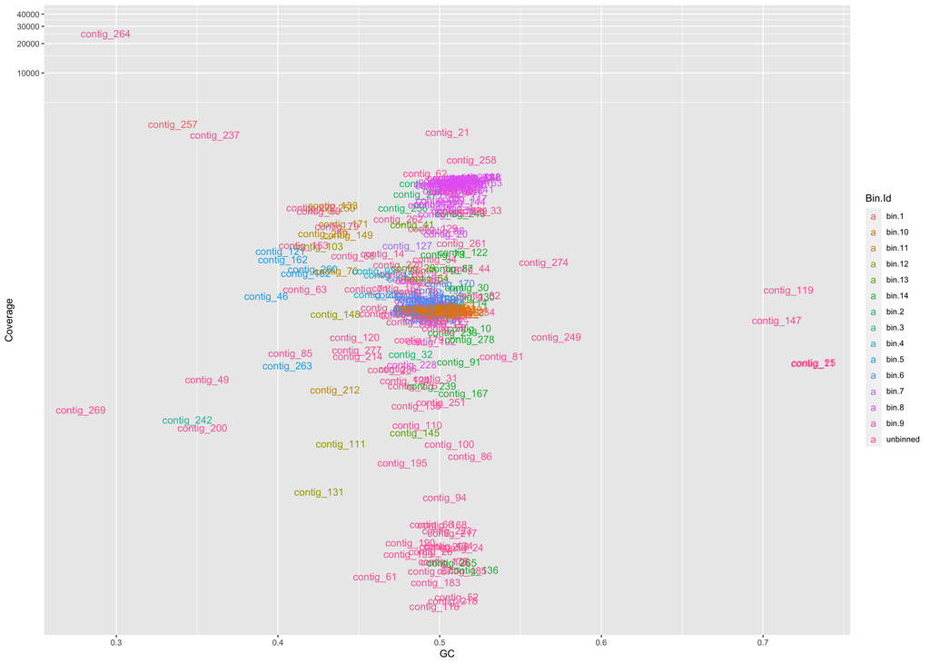

```r
library(tidyverse)
gc3<-read.delim2("../analysis_and_temp_files/02_binning/GTX0501.gc",header=T)
colnames(gc3)[1]<-"contig"
gc3$GC<-as.numeric(gc3$GC)
cov3<-read.delim2("../analysis_and_temp_files/02_binning/GTX0501.cov")
colnames(cov3)[1]<-"contig"
cov3$Coverage<-as.numeric(cov3$Coverage)
df3<-left_join(gc3,cov3)
ggplot(df3,aes(x=GC,y=Coverage,color=Bin.Id))+ coord_trans(y = "log10")+
  #geom_point()+
   geom_text(aes(label=contig))+
  coord_trans(y = "log10")
```

## 2. Screening all bins for MAGs

- CheckM did not identified any bacterial MAGs
- EukCC identified one fungal MAG in bin.8, with 96.99% completeness and 0.75% contamination. Placed it in Parmeliaceae
- EukCC also located some bins with algal marker genes, but failed to place them

```
#!/bin/bash
#SBATCH --time=6:00:00
#SBATCH --cpus-per-task=20
#SBATCH --job-name=eukcc
#SBATCH --output=eukcc.logs.out

mkdir analysis_and_temp_files/02_binning/GTX0501_eukcc
bash code/eukcc.sh analysis_and_temp_files/02_binning/GTX0501.fasta.metabat-bins20-20230618_110806/ analysis_and_temp_files/02_binning/GTX0501_eukcc/GTX0501_eukcc.csv analysis_and_temp_files/02_binning/GTX0501.bam  analysis_and_temp_files/02_binning/GTX0501_eukcc/GTX0501_linktable.csv 20
```

## 3. Finalizing the fungal MAG

- Initial bin is very complete, but probably does not include all contigs

#### Leveraging short read metagenome

- The GC/cov plot of the corresponding short-read metagenome (GTX0466) shows a very clean mycobiont cloud, split between three bins (two in the GC-rich cloud, and one, with lower coverage, in the AT-rich)

```r
illum_binning<-read.delim2("../../01_metagenomics/analysis_and_temp_files/03_assembly/GTX0466_megahit/final.contigs.fa.cov")
illum_binning$Coverage<-as.numeric(illum_binning$Coverage)
illum_binning %>% group_by(Bin.Id) %>% summarise(median_cov=median(Coverage)) %>% filter(median_cov>150)
```

```
## # A tibble: 3 × 2
##   Bin.Id median_cov
##   <chr>       <dbl>
## 1 bin.35       904.
## 2 bin.46       183.
## 3 bin.76       631.
```

- Bin.35 is only 92% complete according to EukCC. Combined, they are 94.74% according to EukCC and 88.1% according to BUSCO. These consist of 1092 contigs

```
cat ../01_Xanthoria_metagenomics/analysis_and_temp_files/03_assembly/GTX0466_megahit/final.contigs.fa.metabat/bin.35.fa ../01_Xanthoria_metagenomics/analysis_and_temp_files/03_assembly/GTX0466_megahit/final.contigs.fa.metabat/bin.46.fa ../01_Xanthoria_metagenomics/analysis_and_temp_files/03_assembly/GTX0466_megahit/final.contigs.fa.metabat/bin.76.fa > analysis_and_temp_files/02_binning/GTX0466_xanthoria_mag.fa

source package ca890cd7-f81d-4c22-9f4a-5b40ab671c79
mkdir analysis_and_temp_files/02_binning/GTX0466_xanthoria_busco
source package 85f2de80-4bd0-48dc-9303-bba1a19206e4
export AUGUSTUS_CONFIG_PATH=analysis_and_temp_files/02_binning/tmp_augustus/config
busco -i  analysis_and_temp_files/02_binning/GTX0466_xanthoria_mag.fa -o GTX0466_xanthoria --out_path analysis_and_temp_files/02_binning/GTX0466_xanthoria_busco  -m  genome -l  /tsl/data/busco_lineages/ascomycota_odb10  --offline -f -c 20

#!/bin/bash
#SBATCH --time=6:00:00
#SBATCH --cpus-per-task=20
#SBATCH --job-name=eukcc
#SBATCH --output=eukcc2.logs.out

mkdir analysis_and_temp_files/02_binning/GTX0466_xanthoria_eukcc
singularity exec ../singularity/eukcc.sif eukcc single --out analysis_and_temp_files/02_binning/GTX0466_xanthoria_eukcc --db /tsl/data/externalData/ntalbot/lichen_project/eukccdb/eukcc2_db_ver_1.2 --threads 20 analysis_and_temp_files/02_binning/GTX0466_xanthoria_mag.fa
```

- Identified all long-read contigs that map to the short-read MAG

```
#!/bin/bash
#SBATCH --time=6:00:00
#SBATCH --cpus-per-task=20
#SBATCH --job-name=minimap
#SBATCH --output=analysis_and_temp_files/02_binning/minimap.logs.out

source package 222eac79-310f-4d4b-8e1c-0cece4150333
minimap2 -x asm20 -t 10 analysis_and_temp_files/02_binning/GTX0466_xanthoria_mag.fa  analysis_and_temp_files/02_binning/GTX0501.fasta > analysis_and_temp_files/02_binning/GTX0501_466.paf
```

- Checked which long-read contigs map to the contigs

```r
library(pafr)
library(GenomicRanges)
```

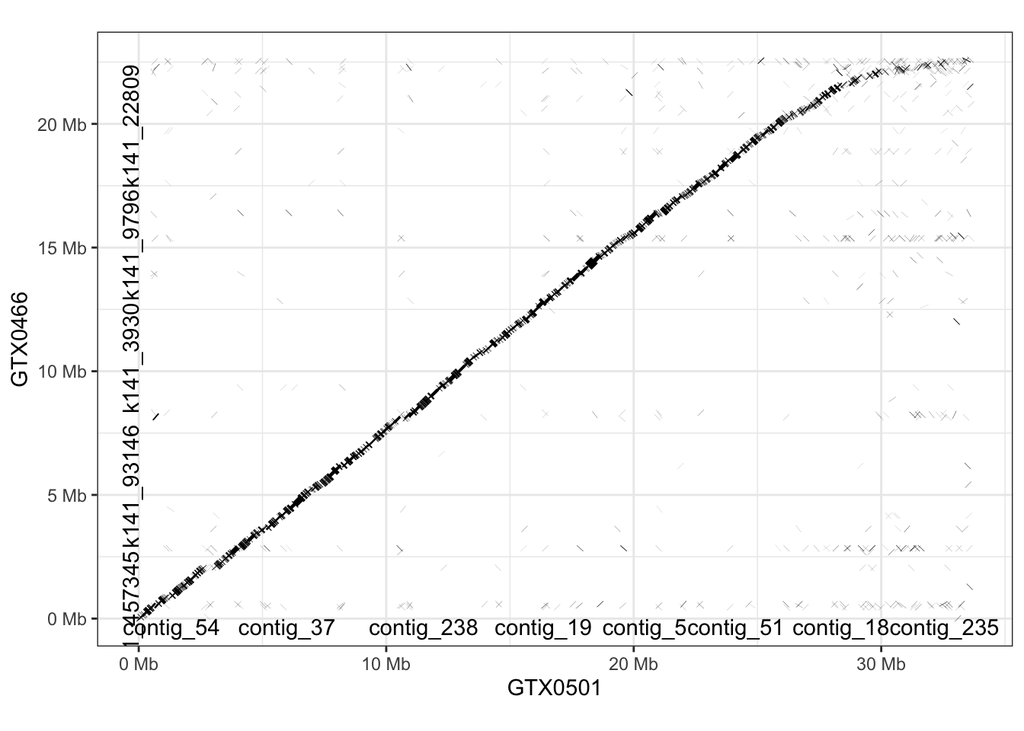

```r
#read and filter the alignemnt file
paf<-read_paf("../analysis_and_temp_files/02_binning/GTX0501_466.paf")
paf_filtered <-filter_secondary_alignments(paf)
paf_filtered <-subset(paf_filtered, alen > 2000 & mapq > 40)
dotplot(paf_filtered,order_by="qstart",label_seqs=T,dashes=F,xlab="GTX0501",ylab="GTX0466") + theme_bw()
```

* Extracted contigs from the long-read assembly, to which I have high-quality alignments from the short-read MAG * Included alignments with >40 mapping quality, and only those where the short-read contig is mapped to a given long-read contig with >75% length * Those included nearly entire bins 8, 11, 14, 4; and entire bins 12, 13, 2, 5, 7; plus 15 of unbinned contigs * Nearly all of them have the best blast hit to fungal genomes. Exceptions are: * contig_233, contig_278: bin.14, hit to bacteria Granulicella and Lysinibacillus macroides * contig_271: bin.2, hit to “uncultured bacterium” * contig_245: bin.4, hit to animal * contig_263: bin.5, hit to “uncultured bacterium” * contig_117 and contig_239: no hits * contig_195: unbinned, hit to animal

```r
#get lengths of the short-read contigs
short_lengths<-data.frame(paf) %>% select(tname,tlen) %>% unique()

#get length of total alignment between pairs of contig and the % of short-read contig aligned
l<- paf_filtered %>% group_split(qname,tname)
get_total_length<-function(x){
  x2<-makeGRangesFromDataFrame(data.frame(x),seqnames.field="tname",start.field="tstart",end.field="tend",ignore.strand=T)
  total_length<-width(GenomicRanges::reduce(x2, ignore.strand=T))
  long_contig<-x$qname[1]
  short_contig<-x$tname[1]
  o<-data.frame("short_contig"=short_contig,"long_contig"=long_contig,"length"=total_length)
  return(o)
}
l2<-lapply(l,get_total_length)
alignment_lengths<-do.call(rbind,l2) %>% left_join(short_lengths,by=c("short_contig"="tname")) %>% mutate(coverage=length/tlen)

## which long-read contigs have short-read contig mapping to them with >75%?
mapping<-alignment_lengths %>% left_join(cov3,by=c("long_contig"="contig")) %>% filter(coverage>0.75) %>% select(long_contig,Bin.Id,Coverage) %>% distinct()

#show blast hits to each contig in the list
blast_hits<-read.csv2("../data/your-data_fg23028_2023-06-08_0827/FG23028_01_info_BLAST-hits.csv",sep=",")
mapping<-mapping %>% left_join(blast_hits %>% select(X.seq_name,cov.,subject.sci.names),by=c("long_contig"="X.seq_name"))
```

```r
mapping %>%
  kable(format = "html", col.names = colnames(mapping)) %>%
  kable_styling() %>%
  kableExtra::scroll_box(width = "100%", height = "600px")
```

| long_contig | Bin.Id | Coverage | cov. | subject.sci.names |
| --- | --- | --- | --- | --- |
| contig_10 | bin.14 | 24.600587 | 17 | Bacidia gigantensis |
| contig_103 | bin.12 | 169.377706 | 16 | Letharia columbiana |
| contig_106 | bin.8 | 850.010778 | 21 | Lachnellula hyalina |
| contig_108 | bin.8 | 867.292912 | 23 | Gaeumannomyces tritici R3-111a-1 |
| contig_111 | bin.12 | 1.613665 | 17 | Fulvia fulva |
| contig_115 | unbinned | 39.896303 | 17 | Phaeoplaca camptidia |
| contig_116 | bin.7 | 78.987098 | 18 | Cercospora sp. J1 LZ-2022 |
| contig_117 | bin.8 | 519.674264 | 11 |  |
| contig_121 | bin.5 | 150.837866 | 16 | Leptosphaeria maculans ‘lepidii’ group |
| contig_122 | bin.14 | 147.233242 | 9 | Colletotrichum lupini |
| contig_127 | bin.7 | 171.259564 | 20 | Lindgomyces ingoldianus |
| contig_129 | unbinned | 259.140370 | 12 | Pichia kudriavzevii |
| contig_13 | bin.8 | 449.582470 | 18 | Thermothielavioides terrestris NRRL 8126 |
| contig_130 | bin.14 | 51.565292 | 16 | Alternaria ventricosa |
| contig_131 | bin.12 | 0.521349 | 16 | Aureobasidium melanogenum |
| contig_133 | bin.11 | 441.553169 | 20 | Fulvia fulva |
| contig_136 | bin.14 | 0.082536 | 17 | Alternaria metachromatica |
| contig_145 | bin.13 | 2.093620 | 17 | Fulvia fulva |
| contig_146 | bin.8 | 620.816965 | 14 | Allantophomopsis cytisporea |
| contig_148 | bin.12 | 34.169444 | 15 | Bacidia gigantensis |
| contig_149 | bin.11 | 222.049463 | 20 | Alternaria solani |
| contig_15 | unbinned | 34.808313 | 20 | Zymoseptoria tritici |
| contig_152 | bin.5 | 89.634025 | 20 | Fulvia fulva |
| contig_153 | unbinned | 173.157921 | 19 | Fulvia fulva |
| contig_16 | bin.8 | 607.793987 | 19 | Letharia columbiana |
| contig_162 | bin.5 | 124.031442 | 19 | Leptosphaeria maculans ‘lepidii’ group |
| contig_167 | bin.14 | 5.294190 | 17 | Baudoinia panamericana UAMH 10762 |
| contig_17 | bin.8 | 832.257911 | 22 | Xanthoria parietina |
| contig_171 | bin.11 | 287.647129 | 17 | Cercospora sp. J1 LZ-2022 |
| contig_18 | bin.8 | 387.988746 | 19 | Rusavskia sp. |

[output cut: 63 more lines]

#### Tried assembling the MAG

- Included:
  - bin.8 (entire). It has all fungal hits, with many Lecanoromycetes
  - bins 11, 12, 13, 7 (entire). Right coverage depth (about 20X according to nanopore, same as bin.8). all hits are fungal, but all are to non-lecanoromycete fungi. Most contigs have lower GC%, about 40%
  - Other contigs with short-read contigs mapped to them, provided they have fungal hits
  - Additional unbinned contigs with Lecanoromycetes hits:
    - contig_258 (rRNA)
    - contig_65
    - contig_185

```r
bins_list<-cov3$contig[cov3$Bin.Id %in% c("bin.8","bin.11","bin.12","bin.13","bin.7")]
unbinned_mapped<-mapping$long_contig[mapping$Bin.Id=="unbinned" & mapping$long_contig!="contig_195"]
manual_adding<-paste0("contig_",c(258,65,185,256,32,93,121,152,162,260,46))
contig_list<-c(bins_list,unbinned_mapped,manual_adding)
write.table(contig_list,"../analysis_and_temp_files/02_binning/GTX0501_candidate_contigs.txt",quote = F, row.names = F, col.names = F)
```

- Identified rRNA contig as contig_258 (identical to ITS sequence from GTX0466 Illumina metagenome, which is placed into X. parietina clade, see `../01_Xanthoria_metagenomics/notebook/03_assembly.html`)
- Identified mitochondrial contig as contig_264 (other hit was contig_269, but it wasn’t blasting as a Lecanoromycetes, and had very low coverage in the illumina reads -> likely a different fungus)

```
source package d6092385-3a81-49d9-b044-8ffb85d0c446
blastn -query analysis_and_temp_files/02_binning/Xanthoria_genbank_mtSSU.fa -subject analysis_and_temp_files/02_binning/GTX0501.fasta -outfmt 6 -out analysis_and_temp_files/02_binning/GTX0501_Xanthoria_genbank_mtSSU.blast
cat analysis_and_temp_files/02_binning/GTX0501_Xanthoria_genbank_mtSSU.blast
>EU680867.1      contig_264      99.216  893     7       0       1       893     4710    5602    0.0     1611
>EU680867.1      contig_269      82.743  904     115     22      22      893     29761   30655   0.0     767
```

#### Created several merged bins and tested with EukCC and BUSCO

- Tested options:
  - bin.8 by itself
  - bin.8 + bin.11
  - bin.8 + unbinned contigs with lecanoromycete hits
  - bin.8 + bin.11 + unbinned contigs with lecanoromycete hits
  - long list with bin.8 + bin.11 + contigs mapped to short-read GTX0466 MAG + unbinned contigs with lecanoromycete hits
- Made combined fasta files

```
mkdir analysis_and_temp_files/02_binning/GTX0501_combined_bins
source package /tgac/software/testing/bin/seqtk-1.0
seqtk subseq analysis_and_temp_files/02_binning/GTX0501.fasta analysis_and_temp_files/02_binning/GTX0501_combined_bins/unbinned_lecanoro_hits.txt > analysis_and_temp_files/02_binning/GTX0501_combined_bins/unbinned_lecanoro_hits.fa

cat analysis_and_temp_files/02_binning/GTX0501.fasta.metabat-bins20-20230618_110806/bin.8.fa analysis_and_temp_files/02_binning/GTX0501.fasta.metabat-bins20-20230618_110806/bin.11.fa > analysis_and_temp_files/02_binning/GTX0501_combined_bins/bin.8.11.fa

cat analysis_and_temp_files/02_binning/GTX0501.fasta.metabat-bins20-20230618_110806/bin.8.fa analysis_and_temp_files/02_binning/GTX0501_combined_bins/unbinned_lecanoro_hits.fa > analysis_and_temp_files/02_binning/GTX0501_combined_bins/bin.8.unbinned.fa

cat analysis_and_temp_files/02_binning/GTX0501.fasta.metabat-bins20-20230618_110806/bin.8.fa analysis_and_temp_files/02_binning/GTX0501.fasta.metabat-bins20-20230618_110806/bin.11.fa  analysis_and_temp_files/02_binning/GTX0501_combined_bins/unbinned_lecanoro_hits.fa > analysis_and_temp_files/02_binning/GTX0501_combined_bins/bin.8.11.unbinned.fa

source package a684a2ed-d23f-4025-aa81-b21e27e458df
seqtk subseq analysis_and_temp_files/02_binning/GTX0501.fasta analysis_and_temp_files/02_binning/GTX0501_candidate_contigs.txt > analysis_and_temp_files/02_binning/GTX0501_combined_bins/GTX0501_candidate_contigs.fa
```

- Ran EukCC

```
#!/bin/bash
#SBATCH --time=6:00:00
#SBATCH --cpus-per-task=20
#SBATCH --job-name=eukcc
#SBATCH --output=eukcc2.logs.out

mkdir analysis_and_temp_files/02_binning/GTX0501_eukcc_combined_bins
singularity exec ../singularity/eukcc.sif eukcc folder --out analysis_and_temp_files/02_binning/GTX0501_eukcc_combined_bins --db /tsl/data/externalData/ntalbot/lichen_project/eukccdb/eukcc2_db_ver_1.2 --threads 20 analysis_and_temp_files/02_binning/GTX0501_combined_bins/
```

- Ran BUSCO

```
source package ca890cd7-f81d-4c22-9f4a-5b40ab671c79
mkdir analysis_and_temp_files/02_binning/GTX0501_busco
source package 85f2de80-4bd0-48dc-9303-bba1a19206e4
export AUGUSTUS_CONFIG_PATH=analysis_and_temp_files/02_binning/tmp_augustus/config
busco -i analysis_and_temp_files/02_binning/GTX0501.fasta.metabat-bins20-20230618_110806/bin.8.fa -o GTX0501_bin8 --out_path analysis_and_temp_files/02_binning/GTX0501_busco  -m  genome -l  /tsl/data/busco_lineages/ascomycota_odb10  --offline -f -c 20

busco -i analysis_and_temp_files/02_binning/GTX0501_combined_bins/bin.8.11.fa -o GTX0501_bin8.bin11 --out_path analysis_and_temp_files/02_binning/GTX0501_busco  -m  genome -l  /tsl/data/busco_lineages/ascomycota_odb10  --offline -f -c 20

busco -i analysis_and_temp_files/02_binning/GTX0501_combined_bins/bin.8.unbinned.fa -o GTX0501_bin8.unbinned --out_path analysis_and_temp_files/02_binning/GTX0501_busco  -m  genome -l  /tsl/data/busco_lineages/ascomycota_odb10  --offline -f -c 20

busco -i analysis_and_temp_files/02_binning/GTX0501_combined_bins/bin.8.11.unbinned.fa -o GTX0501_bin8.bin11.unbinned --out_path analysis_and_temp_files/02_binning/GTX0501_busco  -m  genome -l  /tsl/data/busco_lineages/ascomycota_odb10  --offline -f -c 20

busco -i analysis_and_temp_files/02_binning/GTX0501_combined_bins/GTX0501_candidate_contigs.fa -o GTX0501_candidate --out_path analysis_and_temp_files/02_binning/GTX0501_busco  -m  genome -l  /tsl/data/busco_lineages/ascomycota_odb10  --offline -f -c 20
```

```r
read.delim("../analysis_and_temp_files/02_binning/GTX0501_combined_bins_QC.txt")
```

```
##                 bin                           BUSCO.ascomycota_odb10
## 1             bin.8     C:95.5%[S:95.1%,D:0.4%],F:0.4%,M:4.1%,n:1706
## 2          bin.8.11 C:95.5%[S:95.1%,D:0.4%],F:0.4%,M:4.1%,n:1706\xca
## 3    bin.8.unbinned     C:95.7%[S:95.3%,D:0.4%],F:0.4%,M:3.9%,n:1706
## 4 bin.8.11.unbinned     C:95.7%[S:95.3%,D:0.4%],F:0.4%,M:3.9%,n:1706
## 5 candidate_contigs     C:95.9%[S:95.4%,D:0.5%],F:0.4%,M:3.7%,n:1706
##            EukCC.NCBI.78060..Parmeliaceae.
## 1 96.99% completeness, 0.75% contamination
## 2 96.99% completeness, 0.75% contamination
## 3 97.37% completeness, 0.75% contamination
## 4 97.37% completeness, 0.75% contamination
## 5 97.74% completeness, 1.13% contamination
```

#### Final MAG

- Used bin.8 + bin.11 + unbinned contigs identified as Lecanoromycete
  - Rationale for adding bin.11: it probably represents the AT-rich part of the genome
- Adding all mapped regions increased contamination rate, without adding much to the completeness
- The QC scores are: BUSCO C:95.7%[S:95.3%,D:0.4%],F:0.4%,M:3.9%,n:1706; EukCC: 97.37% completeness, 0.75% contamination
- Saved the file as `analysis_and_temp_files/02_binning/GTX0501_xanthoria_nuclear_mag.fa`. Added contig with rRNA sequence (contig_258)

```
source package 638df626-d658-40aa-80e5-14a275b7464b
samtools faidx analysis_and_temp_files/02_binning/GTX0501.fasta contig_258 > analysis_and_temp_files/02_binning/GTX0501_contig_258_xanthoria_rrna.fa

cat analysis_and_temp_files/02_binning/GTX0501_combined_bins/bin.8.11.unbinned.fa analysis_and_temp_files/02_binning/GTX0501_contig_258_xanthoria_rrna.fa > analysis_and_temp_files/02_binning/GTX0501_xanthoria_nuclear_mag.fa
```

- Saved the mitochondrial contig as `analysis_and_temp_files/02_binning/GTX0501_xanthoria_mitogenome.fa`

```
samtools faidx analysis_and_temp_files/02_binning/GTX0501.fasta contig_264 > analysis_and_temp_files/02_binning/GTX0501_xanthoria_mitogenome.fa
```

## 4. Search for the algal MAG

- Several contigs that had hits to green algae come from:
  - bin.10
  - bin.6
  - unbinned
- Same bins also had hits to animals (mostly fish), plants, and bacteria

#### Test with BUSCO: failed to find a MAG

- Test bins 10 and 6 with BUSCO
  - bin.10: C:3.4%[S:3.4%,D:0.0%],F:0.1%,M:96.5%,n:1519
  - bin.6: C:4.7%[S:4.7%,D:0.0%],F:0.1%,M:95.2%,n:1519
  - bin.14: C:0.1%[S:0.1%,D:0.0%],F:0.0%,M:99.9%,n:1519
  - unbinned: C:0.7%[S:0.7%,D:0.0%],F:0.0%,M:99.3%,n:1519
  - unbinned due to low depth: C:0.9%[S:0.9%,D:0.0%],F:0.0%,M:99.1%,n:1519

```
source package ca890cd7-f81d-4c22-9f4a-5b40ab671c79
mkdir analysis_and_temp_files/02_binning/GTX0501_busco
source package 85f2de80-4bd0-48dc-9303-bba1a19206e4
export AUGUSTUS_CONFIG_PATH=analysis_and_temp_files/02_binning/tmp_augustus/config
busco -i analysis_and_temp_files/02_binning/GTX0501.fasta.metabat-bins20-20230618_110806/bin.10.fa -o GTX0501_bin10 --out_path analysis_and_temp_files/02_binning/GTX0501_busco  -m  genome -l  /tsl/data/busco_lineages/chlorophyta_odb10 --offline -f -c 20

busco -i analysis_and_temp_files/02_binning/GTX0501.fasta.metabat-bins20-20230618_110806/bin.6.fa -o GTX0501_bin6 --out_path analysis_and_temp_files/02_binning/GTX0501_busco  -m  genome -l  /tsl/data/busco_lineages/chlorophyta_odb10 --offline -f -c 20

busco -i analysis_and_temp_files/02_binning/GTX0501.fasta.metabat-bins20-20230618_110806/bin.14.fa -o GTX0501_bin14 --out_path analysis_and_temp_files/02_binning/GTX0501_busco  -m  genome -l  /tsl/data/busco_lineages/chlorophyta_odb10 --offline -f -c 20

busco -i analysis_and_temp_files/02_binning/GTX0501.fasta.metabat-bins20-20230618_110806/bin.unbinned.fa -o GTX0501_unbinned --out_path analysis_and_temp_files/02_binning/GTX0501_busco  -m  genome -l  /tsl/data/busco_lineages/chlorophyta_odb10 --offline -f -c 20

busco -i analysis_and_temp_files/02_binning/GTX0501.fasta.metabat-bins20-20230618_110806/bin.lowDepth.fa -o GTX0501_lowdepth --out_path analysis_and_temp_files/02_binning/GTX0501_busco  -m  genome -l  /tsl/data/busco_lineages/chlorophyta_odb10 --offline -f -c 20
```

- Analyzed the whole assembly, to check whether it contains enough algal markers - which it doesn’t
  - C:46.3%[S:44.6%,D:1.7%],F:2.0%,M:51.7%,n:1519

  ```
  busco -i analysis_and_temp_files/02_binning/GTX0501.fasta -o GTX0501_assembly --out_path analysis_and_temp_files/02_binning/GTX0501_busco  -m  genome -l  /tsl/data/busco_lineages/chlorophyta_odb10 --offline -f -c 20
  ```

#### Identified marker contigs

- rRNA: two contigs, which overlap almost exactly, but have flanking regions on different sides
  - contig_34: hit to Trebouxia ITS, noncircular, coverage 23 in Nanopore reads, 125 in Illumina
  - contig_243: hit to Trebouxia ITS, noncircular, coverage 54 in Nanopore reads, 96 in Illumina
- Organell genomes:
  - contig_257: hit to Trebouxia chloroplast, circular, coverage 64X in Nanopore reads, 3000X in Illumina
  - contig_242: hit to Trebouxia chloroplast, noncircular, coverage 11 in Nanopore reads, 3 in Illumina
  - contig_237: hit to Trebouxia mitochondrion, circular, coverage 51 in Nanopore reads, 2330 in Illumina
  - contig_200: hit to Trebouxia mitochondrion, noncircular, coverage 5 in Nanopore reads, 2 in Illumina

#### Results: no algal MAG, but two pairs of mitochonrial and plastid genomes

## 5. Xanthoria parietina (GTX0501) results

### Visualize quality

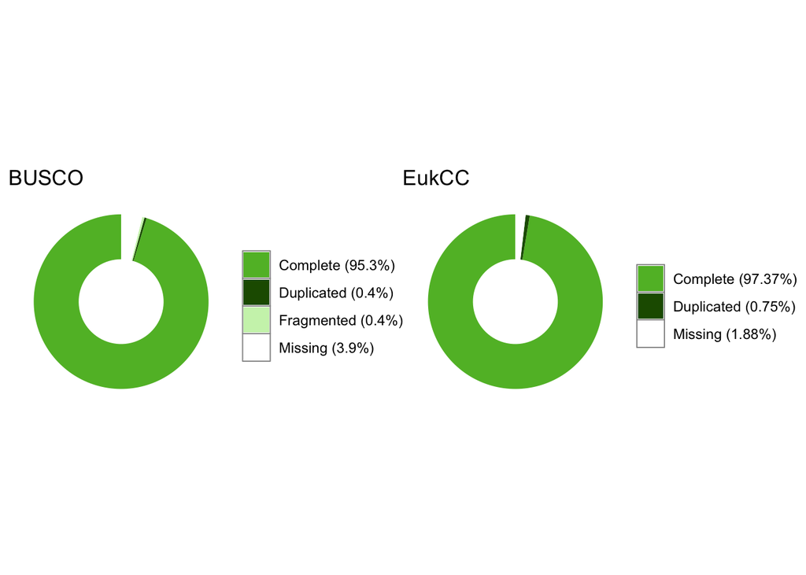

```r
library(tidyverse)
library(geomtextpath)
library(patchwork)

busco<-data.frame("type"=c("Complete (95.3%)","Duplicated (0.4%)","Fragmented (0.4%)","Missing (3.9%)"),
             "percent"=c(95.3,0.4,0.4,3.9))
hsize <- 1.5
busco$x<-hsize

b<-ggplot(busco,aes(y=percent,fill=type,x=hsize))+geom_col()+
  coord_curvedpolar(theta = "y")+  xlim(c(0.2, hsize + 0.5))+
  scale_fill_manual(values=c("Complete (95.3%)"="#60ba30","Duplicated (0.4%)"="#1f5900","Fragmented (0.4%)"="#ccf2b8","Missing (3.9%)"="white"))+
  theme_void()+theme(legend.title = element_blank(),legend.text = element_text(size=9),
                     legend.key=element_rect(colour="#969696"))+ggtitle("BUSCO")

eukcc<-data.frame("type"=c("Complete (97.37%)","Duplicated (0.75%)","Missing (1.88%)"),
             "percent"=c(97.37,0.75,1.88))
eukcc$x<-hsize

e<-ggplot(eukcc,aes(y=percent,fill=type,x=hsize))+geom_col()+
  coord_curvedpolar(theta = "y")+  xlim(c(0.2, hsize + 0.5))+
  scale_fill_manual(values=c("Complete (97.37%)"="#60ba30","Duplicated (0.75%)"="#1f5900","Fragmented (0.4%)"="#ccf2b8","Missing (1.88%)"="white"))+
  theme_void()+theme(legend.title = element_blank(),legend.text = element_text(size=9),
                     legend.key=element_rect(colour="#969696"))+ggtitle("EukCC")

b+e
```

- Save the figure

```r
plot<-b+theme(title = element_text(size=8),legend.text = element_text(size=7))+
  e+theme(title = element_text(size=8),legend.text = element_text(size=7))
ggsave('../results/busco.pdf',plot, width = 5, height = 2.5)
```